# project01-sarah-santiago

Sarah Santiago

9/23/2020

# Project 1: Hurricanes Data

## The Data

> In this project, we look at data from the *International Best Track Archive for Climate Stewardship(IB-TrACS)* website that can be found here: https://www.ncei.noaa.gov/data/international-best-track-archive-for-climate-stewardship-ibtracs/v04r00/access/csv/

> The data contains hurricane data in the North Atlantic from years 1980 to 2019. Through data analysis and visualizations we will be able to see key weather patterns regarding hurricanes.

Now, let’s upload the first 16 columns of the data to analyze the data further.

```r
# download copy of csv
origin <- 'https://www.ncei.noaa.gov/data/international-best-track-archive-for-climate-stewardship-ibtracs/v04r00/access/csv/ibtracs.NA.list.v04r00.csv'
destination <- 'hurricane.csv'
download.file(origin, destination)
```

```r
#column types of 16 wanted columns
col_types <- c('character', 'integer', 'integer', 'character', 'character', 'character', 'character', 'character', 'double', 'double', 'integer', 'integer', 'character', 'character', 'integer', 'integer')

#column names of first 16 columns
col_names <- c("SID", "SEASON", "NUMBER", "BASIN", "SUBBASIN", "NAME", "ISO_TIME", "NATURE", 'LAT', "LON", "WMO_WIND", "WMO_PRES", "WMO_AGENCY", "TRACK_TYPE", "DIST2LAND",  "LANDFALL")

#read first 16 columns of csv file
hurricanes <- read.csv(file = "hurricane.csv",
                       colClasses = c(col_types, rep("NULL", 147)),
                       skip = 86272,
                       na.strings = " ",
                       stringsAsFactors = FALSE)

#give column names to data
colnames(hurricanes) <- col_names
head(hurricanes, 5)
```

```
##             SID SEASON NUMBER BASIN SUBBASIN      NAME            ISO_TIME
## 1 1980199N31284   1980     49    NA       NA NOT_NAMED 1980-07-17 00:00:00
## 2 1980199N31284   1980     49    NA       NA NOT_NAMED 1980-07-17 03:00:00
## 3 1980199N31284   1980     49    NA       NA NOT_NAMED 1980-07-17 06:00:00
## 4 1980199N31284   1980     49    NA       NA NOT_NAMED 1980-07-17 09:00:00
## 5 1980199N31284   1980     49    NA       NA NOT_NAMED 1980-07-17 12:00:00
##   NATURE     LAT      LON WMO_WIND WMO_PRES WMO_AGENCY TRACK_TYPE DIST2LAND
## 1     TS 30.5000 -76.5000       20       NA hurdat_atl       main       390
## 2     TS 30.3428 -76.8528       NA       NA       <NA>       main       382
## 3     TS 30.2000 -77.2000       25       NA hurdat_atl       main       371
## 4     TS 30.0845 -77.5549       NA       NA       <NA>       main       332
## 5     TS 30.0000 -78.0000       25       NA hurdat_atl       main       294
##   LANDFALL
## 1      379
## 2      371
## 3      341
## 4      294
## 5      239
```

```r
# adding month column
hurricanes$MONTH <-as.numeric(substr(hurricanes$ISO_TIME, 6, 7))

#take out year 2020 because we are only analyzing until 2019
hurricanes <- filter(hurricanes, SEASON != 2020)

# display structure of data
str(hurricanes, vec.len = 1)
```

```
## 'data.frame':    34535 obs. of  17 variables:
##  $ SID       : chr  "1980199N31284" ...
##  $ SEASON    : int  1980 1980 ...
##  $ NUMBER    : int  49 49 ...
##  $ BASIN     : chr  "NA" ...
##  $ SUBBASIN  : chr  "NA" ...
##  $ NAME      : chr  "NOT_NAMED" ...
##  $ ISO_TIME  : chr  "1980-07-17 00:00:00" ...
##  $ NATURE    : chr  "TS" ...
##  $ LAT       : num  30.5 ...
##  $ LON       : num  -76.5 ...
##  $ WMO_WIND  : int  20 NA ...
##  $ WMO_PRES  : int  NA NA ...
##  $ WMO_AGENCY: chr  "hurdat_atl" ...
##  $ TRACK_TYPE: chr  "main" ...
##  $ DIST2LAND : int  390 382 ...
##  $ LANDFALL  : int  379 371 ...
##  $ MONTH     : num  7 7 ...
```

## Univariate Exploratory Data Analysis

To get familiarized with the data, I will be going through some columns to see basic stats/features of the contents of the columns. These preliminary notes and findings on individual columns will help with further analysis.

### SEASON

```r
#range of years

unique(hurricanes[['SEASON']])[c(1, 40)]
```

```
## [1] 1980 2019
```

```r
#Number of storms per year organized from greatest to least

hurricanes %>%
  group_by(SEASON) %>%
  count() %>%
  arrange(desc(n)) %>%
  head(5)
```

```
## # A tibble: 5 x 2
## # Groups:   SEASON [5]
##   SEASON     n
##    <int> <int>
## 1   2005  1807
## 2   1995  1481
## 3   2010  1281
## 4   2012  1267
## 5   2017  1190
```

### BASIN

```r
#get unique types of basins

unique(hurricanes["BASIN"])
```

```
##      BASIN
## 1       NA
## 5442    EP
```

From this, we see only basins in the North Atlantic and the Eastern North Pacific are in the dataset.

```r
#Number of hurricanes per year

hurricanes %>%
  group_by(BASIN) %>%
  count()
```

```
## # A tibble: 2 x 2
## # Groups:   BASIN [2]
##   BASIN     n
##   <chr> <int>
## 1 EP      198
## 2 NA    34337
```

Looking at this, hurricanes primarily occur in the North Atlantic.

### SUBBASIN

```r
#get unique types of subbasins and their counts

hurricanes %>%
  group_by(SUBBASIN) %>%
  count()
```

```
## # A tibble: 4 x 2
## # Groups:   SUBBASIN [4]
##   SUBBASIN     n
##   <chr>    <int>
## 1 CS        3514
## 2 GM        3025
## 3 MM         198
## 4 NA       27798
```

### WMO_WIND

```r
#Summary statistics of wind data

summary(hurricanes['WMO_WIND'])
```

```
##     WMO_WIND
##  Min.   : 10.00
##  1st Qu.: 30.00
##  Median : 40.00
##  Mean   : 48.87
##  3rd Qu.: 60.00
##  Max.   :165.00
##  NA's   :16721
```

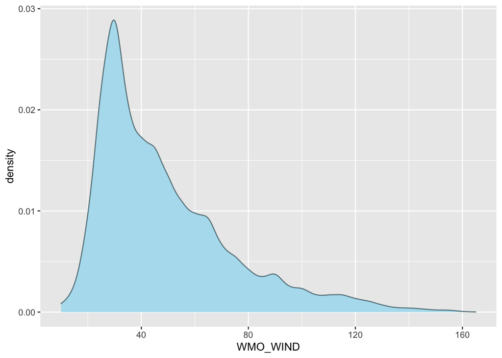

```r
#Seeing the distribution of wind data

ggplot(hurricanes, aes(x = WMO_WIND)) + geom_density(fill = "lightblue2",  color = 'lightblue4')
```

The bulk of the data has wind speeds of around 30-70.

### WMO_PRES

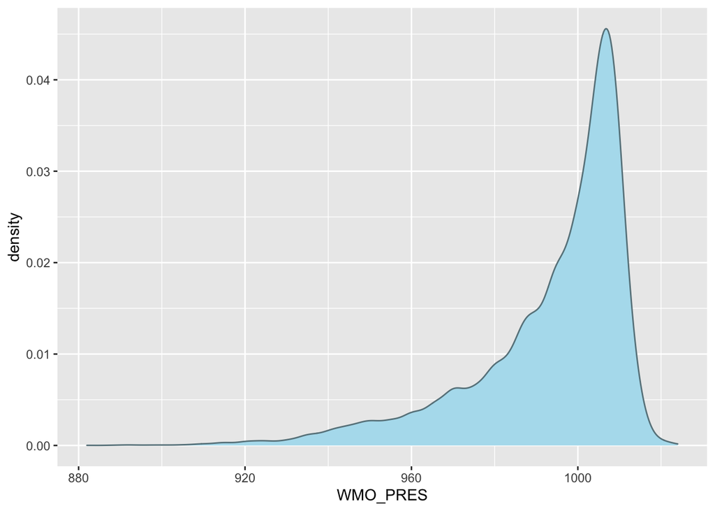

```r
#Seeing the distribution of pressure data

ggplot(hurricanes, aes(x = WMO_PRES)) + geom_density(fill = "lightblue2", color = 'lightblue4')
```

We can see the storms generally have higher pressure.

### LATITUDE/LONGITUDE

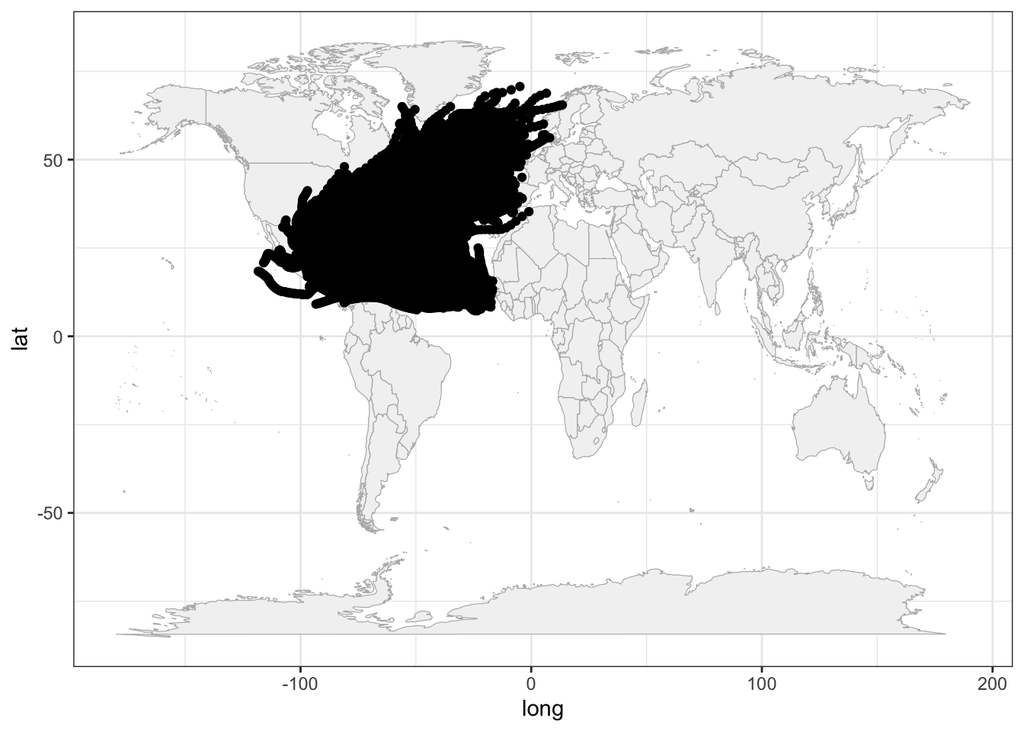

```r
world_map <- map_data("world")

world <- ggplot() +
  geom_polygon(data = world_map,
               aes(x = long, y = lat, group = group),
               fill = "gray95", colour = "gray70", size = 0.2) +
  theme_bw()

world +
  geom_point(data = hurricanes, aes(x = LON, y = LAT))
```

Looking at this visualization, most storms occurred in a specific region of the world.

## Further Analysis

Using the data, we want to answer four key research questions:

> 1. A typical hurricane season (during a calendar year) runs from June through November, but occasionally storms form outside those months.
> 2. A typical year has 12 named storms, including six hurricanes of which three become major hurricanes (category 3, 4, and 5).
> 3. September is the most active month (where most of the hurricanes occur), followed by August, and October.
> 4. During the analyzed period (1980-2019), no hurricanes made U.S. landfall before June and after November.

## Research Question 1

> 1. A typical hurricane season (during a calendar year) runs from June through November, but occasionally storms form outside those months.

To answer this question, we wanted to see how many storms happen per month to see if this claim stands. First off, we can look at a histogram displaying the count of storms by looking at the `MONTH` column. Looking at this visualization, we can see the bulk of months with the most storms were indeed from June through November.

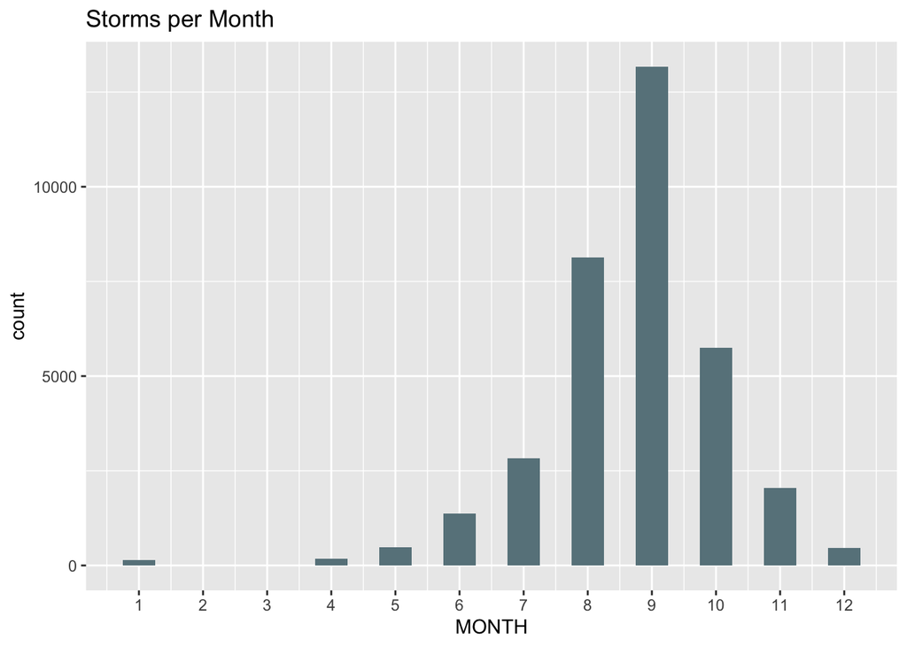

```r
#See how many storms happen per month

ggplot(hurricanes, aes(x = MONTH)) +
  geom_histogram(fill = "lightblue4", binwidth = .5) +
  scale_x_continuous(n.breaks = 10) +
  ggtitle("Storms per Month")
```

```r
#Look at the months not between June and November
off_season <- hurricanes %>%
                 filter(MONTH %in% c(1, 2, 3, 4, 5, 12))
head(off_season, 5)
```

```
##             SID SEASON NUMBER BASIN SUBBASIN      NAME            ISO_TIME
## 1 1981097N21299   1981     28    NA       NA NOT_NAMED 1981-04-06 12:00:00
## 2 1981097N21299   1981     28    NA       NA NOT_NAMED 1981-04-06 15:00:00
## 3 1981097N21299   1981     28    NA       NA NOT_NAMED 1981-04-06 18:00:00
## 4 1981097N21299   1981     28    NA       NA NOT_NAMED 1981-04-06 21:00:00
## 5 1981097N21299   1981     28    NA       NA NOT_NAMED 1981-04-07 00:00:00
##   NATURE     LAT      LON WMO_WIND WMO_PRES WMO_AGENCY TRACK_TYPE DIST2LAND
## 1     TS 21.0000 -61.5000       25       NA hurdat_atl       main       518
## 2     TS 20.5625 -61.7729       NA       NA       <NA>       main       468
## 3     TS 20.2000 -62.1000       30       NA hurdat_atl       main       418
## 4     TS 19.9501 -62.5073       NA       NA       <NA>       main       371
## 5     TS 19.7000 -62.9000       30       NA hurdat_atl       main       318
##   LANDFALL MONTH
## 1      468     4
## 2      418     4
## 3      371     4
## 4      318     4
## 5      276     4
```

```r
#Percentage of storms occurring in the off season
(nrow(off_season) / nrow(hurricanes)) * 100
```

```
## [1] 3.657159
```

Taking a closer look, I made a dataframe with the claimed off-season months. With this new dataframe, I was able to calculate the percentage of storms that happen in the off season and it was **3.66%** of all storms.

> **Conclusion:**  
> Looking at both the visualization and the fact that only 3.66% of storms happen in off-season months, we can conclude that the original claim was true. **Most storms do occur between the months of June through November.**

## Research Question 2

> 2. A typical year has 12 named storms, including six hurricanes of which three become major hurricanes (category 3, 4, and 5).

To answer this, I began by checking if the first claim, a typical year has 12 named storms, would hold to be reasonable. I did this by creating a new dataframe called `named` which contained all of the named storms in our original table. Using this, I found storms and the years they occurred in. A new dataframe `named_per_year` was made that found the count of storms that happened each year.

```r
#Named storms
named <- filter(hurricanes, NAME != "NOT_NAMED")

#find storms and their years
storms_years <- named %>%
         group_by(NAME, SEASON) %>%
         count()

#Number of named storms per year
named_per_year <- storms_years %>%
                    group_by(SEASON) %>%
                    count()

head(named_per_year, 5)
```

```
## # A tibble: 5 x 2
## # Groups:   SEASON [5]
##   SEASON     n
##    <int> <int>
## 1   1980    11
## 2   1981    11
## 3   1982     5
## 4   1983     4
## 5   1984    12
```

Using `named_per_year`, I produced the following histogram which displays the count of **named storms per year**. Additionally, a red line was added to mark if a year made the 12 named storms cutoff as made in the initial claim. Visually, you can see a little more than half of all years have 12 or more named storms. Computationally, I calculated that **55%** of all years had 12 or more named storms.

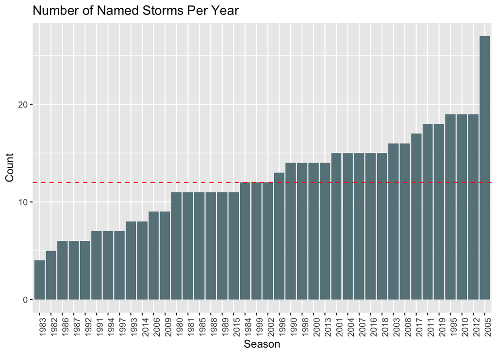

```r
#Plot of the number of named storms per year
ggplot(named_per_year, aes(x = reorder(SEASON, n), y = n)) +
  geom_histogram(stat = 'identity', fill = "lightblue4") +
  geom_hline(yintercept=12, linetype="dashed", color = "red") +
  theme(axis.text.x = element_text(angle = 90)) +
  xlab("Season") +
  ylab("Count") +
  ggtitle("Number of Named Storms Per Year")
```

```r
#Seeing percentage of years that have 12 or more storms

length(filter(named_per_year, n >= 12)[['n']]) / length(named_per_year[['n']])
```

```
## [1] 0.55
```

Looking at the summary statistics, we can see that the *median* amount of named storms is 12. Though the median amount of storms per year is 12, I would not claim definitively that a typical year has 12 or more storms. Taking into account the fact that only 55% of years had 12 or more storms, it would be safer if the cutoff was perhaps 10 or more storms per year. This would make it so 70% of years have 10 or more storms per year.

```r
#Summary statistics for number of named storms per year

summary(named_per_year['n'])
```

```
##        n
##  Min.   : 4.00
##  1st Qu.: 8.75
##  Median :12.00
##  Mean   :12.43
##  3rd Qu.:15.00
##  Max.   :27.00
```

Now, I wanted to explore the second part of the claim, namely that a typical year has 6 hurricanes and 3 of which are major hurricanes (categories 3, 4, or 5). To do this I made a new dataframe, `hurricanes_per_year`, which grouped wind speeds from `named` by name and season and took their count. Only wind counts greater than or equal to 64 were taken since any speed above this is considered a hurricane (anything lower is classified as a tropical storm).

```r
#Number of hurricanes per year
#Hurricanes are defined as having a wind speed over 64

hurricanes_per_year <- named %>%
                          filter(WMO_WIND >= 64) %>%
                          group_by(NAME, SEASON) %>%
                          count() %>%
                          group_by(SEASON) %>%
                          count()

head(hurricanes_per_year, 5)
```

```
## # A tibble: 5 x 2
## # Groups:   SEASON [5]
##   SEASON     n
##    <int> <int>
## 1   1980     9
## 2   1981     7
## 3   1982     2
## 4   1983     3
## 5   1984     5
```

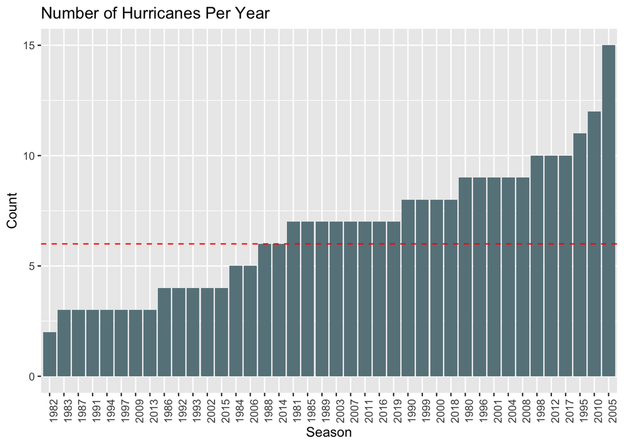

```r
#histogram of the number of hurricanes per year

ggplot(hurricanes_per_year, aes(x = reorder(SEASON, n), y = n)) +
  geom_histogram(stat = 'identity', fill = "lightblue4") +
  geom_hline(yintercept=6, linetype="dashed", color = "red") +
  theme(axis.text.x = element_text(angle = 90)) +
  xlab("Season") +
  ylab("Count") +
  ggtitle("Number of Hurricanes Per Year")
```

```r
# percentage of years that had 6 or more hurricanes per year

sum(filter(hurricanes_per_year, n >= 6)[['n']]) / sum(hurricanes_per_year[['n']])
```

```
## [1] 0.8007519
```

```r
# percentage of years that had exactly 6

sum(filter(hurricanes_per_year, n == 6)[['n']]) / sum(hurricanes_per_year[['n']])
```

```
## [1] 0.04511278
```

```r
#Summary statistics for number of hurricanes per year
summary(hurricanes_per_year['n'])
```

```
##        n
##  Min.   : 2.00
##  1st Qu.: 4.00
##  Median : 7.00
##  Mean   : 6.65
##  3rd Qu.: 9.00
##  Max.   :15.00
```

Lastly, I checked the claim that 3 of the named storms per year are major hurricanes (categories 3, 4, or 5). A new dataframe, `major`, was created that took the counts of all of the rows in `named` that had wind speeds greater than or equal to 96 as this is considered a major hurricane.

```r
#Number of major hurricanes per year
#Major hurricanes have wind speeds over 96

major <- named %>%
            filter(WMO_WIND >= 96) %>%
            group_by(NAME, SEASON) %>%
            count() %>%
            group_by(SEASON) %>%
            count()

head(major, 5)
```

```
## # A tibble: 5 x 2
## # Groups:   SEASON [5]
##   SEASON     n
##    <int> <int>
## 1   1980     2
## 2   1981     3
## 3   1982     1
## 4   1983     1
## 5   1984     1
```

The number of major hurricanes was plotted in a histogram by year. Again, the red line signifies having a count of 3 major hurricanes in a year. Only **45%** of years had 3 or more hurricanes per year. According to the summary statistics, the median number of hurricanes is 2 hurricanes per year.

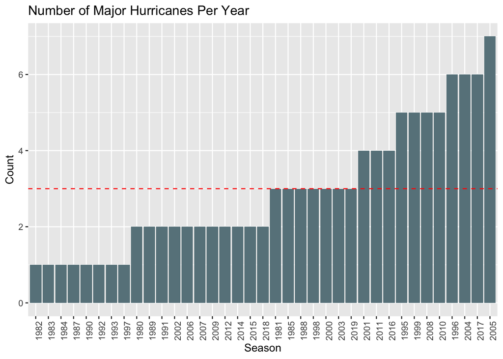

```r
ggplot(major, aes(x = reorder(SEASON, n), y = n)) +
  geom_histogram(stat = 'identity', fill = "lightblue4") +
  geom_hline(yintercept=3, linetype="dashed", color = "red") +
  theme(axis.text.x = element_text(angle = 90)) +
  xlab("Season") +
  ylab("Count") +
  ggtitle("Number of Major Hurricanes Per Year")
```

```r
#Summary statistics for number of major hurricanes per year
summary(major['n'])
```

```
##        n
##  Min.   :1.000
##  1st Qu.:2.000
##  Median :2.000
##  Mean   :2.919
##  3rd Qu.:4.000
##  Max.   :7.000
```

```r
#Percentage of hurricanes >= 3
#Add 3 to account for the 3 years that had zero major hurricanes

length(filter(major, n >= 3)[['n']]) / (length(major[['n']]) + 3)
```

```
## [1] 0.45
```

## Research Question 3

> 3. September is the most active month (where most of the hurricanes occur), followed by August, and October.

For this, I wanted to look at the counts of hurricanes per month to see what were the months with the most hurricanes. `hurricanes_only` is a dataframe that contains all of the hurricanes (rows with wind speeds greater than or equal to 64). A summary of this dataframe shows that the median of the months is 9. Making a histogram of `hurricanes_only` based on month showed that month 9 (September) has the most hurricanes. This was followed by months 8 (August) and 10 (October).

```r
#Get a table with data of ONLY hurricanes (ie. tropical storms excluded)
hurricanes_only <- hurricanes %>%
                    filter(WMO_WIND >= 64)

head(hurricanes_only, 5)
```

```
##             SID SEASON NUMBER BASIN SUBBASIN  NAME            ISO_TIME NATURE
## 1 1980214N11330   1980     57    NA       NA ALLEN 1980-08-03 00:00:00     TS
## 2 1980214N11330   1980     57    NA       NA ALLEN 1980-08-03 06:00:00     TS
## 3 1980214N11330   1980     57    NA       NA ALLEN 1980-08-03 12:00:00     TS
## 4 1980214N11330   1980     57    NA       NA ALLEN 1980-08-03 18:00:00     TS
## 5 1980214N11330   1980     57    NA       NA ALLEN 1980-08-04 00:00:00     TS
##    LAT   LON WMO_WIND WMO_PRES WMO_AGENCY TRACK_TYPE DIST2LAND LANDFALL MONTH
## 1 12.4 -51.4       65      985 hurdat_atl       main       790      762     8
## 2 12.6 -53.6       70      980 hurdat_atl       main       753      713     8
## 3 12.8 -55.6       80      975 hurdat_atl       main       633      543     8
## 4 12.9 -57.5       95      965 hurdat_atl       main       453      398     8
## 5 13.3 -59.1      110      950 hurdat_atl       main       357      321     8
```

```r
#Summary table of months of hurricanes
summary(hurricanes_only['MONTH'])
```

```
##      MONTH
##  Min.   : 1.000
##  1st Qu.: 8.000
##  Median : 9.000
##  Mean   : 8.959
##  3rd Qu.: 9.000
##  Max.   :12.000
```

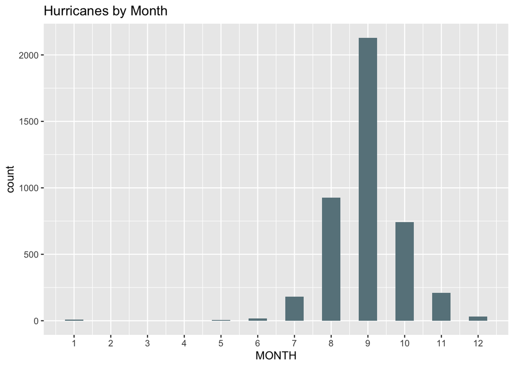

```r
#Histogram of the hurricanes by month

ggplot(hurricanes_only, aes(x = MONTH)) +
  geom_histogram(binwidth = .5, fill = 'lightblue4') +
  scale_x_continuous(n.breaks = 10) +
  ggtitle("Hurricanes by Month")
```

Just to verify the visualization above, the dataframe below shows the top three months with the highest hurricane counts. Those months were indeed September, August, and October.

```r
#Taking counts of hurricanes to see top three most active months

hurricanes_only %>%
  group_by(MONTH) %>%
  count() %>%
  arrange(desc(n)) %>%
  head(3)
```

```
## # A tibble: 3 x 2
## # Groups:   MONTH [3]
##   MONTH     n
##   <dbl> <int>
## 1     9  2129
## 2     8   927
## 3    10   742
```

> **Conclusion:**  
> After looking at the histogram and dataframe of the counts of months with highest hurricane counts, **September, August, and October were the most active months**. This analysis showed the initial claim holds.

## Research Question 4

> 4. During the analyzed period (1980-2019), no hurricanes made U.S. landfall before June and after November.

To see what hurricanes made landfall, I filtered `hurricanes_only` to show only the months before June and after November and checked what rows had `LANDFALL` equal to zero. The resulting table shows hurricane Barbara made landfall. The location being `EP` (Eastern North Pacific) suggests that it could have made landfall in the United States. A map was created to check this.

```r
#Checking the hurricanes only table to see if any hurricanes made landfall before June and after November

hurricanes_only %>%
  filter(MONTH < 6 | MONTH == 12) %>%
  filter(LANDFALL == 0)
```

```
##             SID SEASON NUMBER BASIN SUBBASIN    NAME            ISO_TIME NATURE
## 1 2013149N14264   2013     22    EP       MM BARBARA 2013-05-29 18:00:00     TS
## 2 2013149N14264   2013     22    EP       MM BARBARA 2013-05-29 19:50:00     TS
##    LAT   LON WMO_WIND WMO_PRES WMO_AGENCY TRACK_TYPE DIST2LAND LANDFALL MONTH
## 1 15.7 -94.2       65      986 hurdat_epa       main        39        0     5
## 2 16.0 -94.0       70      983 hurdat_epa       main         0        0     5
```

A map was made displaying the location of hurricanes that occurred before June and after November using latitude and longitudes. Only one hurricane, Barbara, made landfall, however, it did not make U.S landfall.

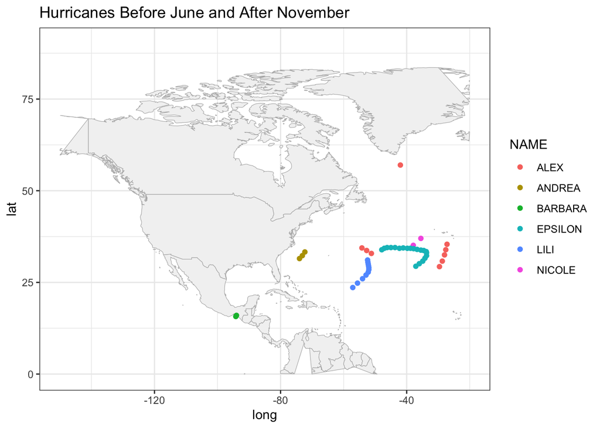

```r
#Plot the longitudes and latitudes of storms to see if any made US landfall

world +
  geom_point(data = filter(hurricanes_only, MONTH < 6 | MONTH == 12), aes(x = LON, y = LAT, color = NAME)) +
  xlim(c(-150, -20)) +
  ylim(c(0, 90)) +
  ggtitle('Hurricanes Before June and After November')
```

> **Conclusion:**  
> In conclusion, **no hurricanes made U.S. landfall before June and after November**. Looking at the map of hurricanes that occurred before and after November confirms that no hurricanes made landfall in the United States.

### Link to Video: https://berkeley.zoom.us/rec/share/zSRBoxwtW0aLMVO2-VtKSIv1N0YhB_Iri81v5ScrszH4XR85AYawtCeQmsQvs-Vk.uYDEpuAaYZ8zaSGT?startTime=1601773229000